# Waterfowl - LTEM - Hai Lake Mount Herman Provincial Park

Published

2023-02-23

# 1 Summary of Waterfowl LTEM protocol

## 1.1 Basic protocol

As taken from the protocol document:

> “Establish observation points at enough sites to provide views of the entire survey area. …

> Choose a date after which migrants are mostly gone. Count on 3 separate occasions during a 2-3 week period and keep > highest count.”

## 1.2 Cautions about the protocol.

### 1.2.1 Don’t use 0 to indicate a missing value.

If no species were seen during a visit, this is indicated by the species code being set to missing and the count field being set to 0. This needs to be done consistently over time.

If no visit was made to a station in a year, then there are no records in the database.

### 1.2.2 Classifying by season

The protocol is silent about seasonal sampling, e.g., spring vs. fall. There is some issue on how to properly pool information that is close together but crosses year boundaries. For example, surveys may be done in late December of 2013 and early January of 2014. If the maximum counts over multiple visits in the winter are collected, visits on these two months need to be “combined” even though they are in different calendar years.

For this analysis we classified by month (November, December, January, February) to avoid this problem

## 1.3 Database structure

The relevant fields from the database are:

- *SAMPLE_LABEL*. The label for the location where data was located.
- *Date*. The date the data was collected. The *Year* is extracted from this date.
- *Species*. What species were seen
- *Count*. Count of the number of birds of each species.

# 2 Reading and checking the data

The following surveys were found:

```
Surveys with the data
```

```
   SPI_PROJECT_ID SURVEY_ID          START_DATE
12           5516     35486 2015-04-14 17:00:00
18           5516     35492 2016-03-13 17:00:00
22           5516     35496 2017-05-24 17:00:00
40           5516     40565 2018-03-31 17:00:00
47           5516     40572 2019-03-31 17:00:00
52           5516     40577 2020-04-30 17:00:00
67           5516     47242 2021-05-13 17:00:00
                         STUDY_AREA_NAME
12 Hai Lake Mount Herman Provincial Park
18 Hai Lake Mount Herman Provincial Park
22 Hai Lake Mount Herman Provincial Park
40 Hai Lake Mount Herman Provincial Park
47 Hai Lake Mount Herman Provincial Park
52 Hai Lake Mount Herman Provincial Park
67 Hai Lake Mount Herman Provincial Park
```

The following data editing was performed

## 2.1 Variables names corrected for *R*

Variable names in *R* must start with a letter and contain letters or numbers or underscores. Blanks in variable names are not normally allowed, nor are special characters such as %. These are normally replaced by periods (“.”) in the variable name.

```
Original variable names in data frame
```

```
  [1] "DESIGN_COMPONENT_ID"            "TAXONOMIC_UNIT_ID"
  [3] "SURVEY_ID"                      "SPI_PROJECT_ID"
  [5] "STUDY_AREA_ID"                  "STUDY_AREA_VISIT_ID"
  [7] "DESIGN_COMPONENT_VISIT_ID"      "VISIT_START_DATE"
  [9] "VISIT_START_TIME"               "OBSERVATION_DATETIME"
 [11] "OBSERVATION_YEAR"               "OBSERVATION_MONTH"
 [13] "OBSERVATION_DAY"                "VISIT_END_DATE"
 [15] "VISIT_END_TIME"                 "VISIT_TIME_SPAN"
 [17] "VISIT_TIME_SPAN_UNIT_CODE"      "VISIT_TIME_SPAN_UNIT_NAME"
 [19] "VISIT_TIME_SPAN_UNIT_DEFN_URL"  "TRAP_EVENT_CODE"
 [21] "TRAP_EVENT_NAME"                "TRAP_EVENT_DEFN_URL"
 [23] "TRAPS_SPRUNG"                   "DISTANCE_COVERED_KM"
 [25] "NIGHTS_TRAPPED"                 "SAMPLES"
 [27] "VISIT_NOTE"                     "NO_OBSERVATIONS_IND"
 [29] "TRIGGER_QUIET_PERIOD_SEC"       "TRIGGER_SENSITIVITY"
```

[output cut: 44 more lines]

```
Corrected variable names of data frame
```

```
  [1] "DESIGN_COMPONENT_ID"            "TAXONOMIC_UNIT_ID"
  [3] "SURVEY_ID"                      "SPI_PROJECT_ID"
  [5] "STUDY_AREA_ID"                  "STUDY_AREA_VISIT_ID"
  [7] "DESIGN_COMPONENT_VISIT_ID"      "VISIT_START_DATE"
  [9] "VISIT_START_TIME"               "OBSERVATION_DATETIME"
 [11] "OBSERVATION_YEAR"               "OBSERVATION_MONTH"
 [13] "OBSERVATION_DAY"                "VISIT_END_DATE"
 [15] "VISIT_END_TIME"                 "VISIT_TIME_SPAN"
 [17] "VISIT_TIME_SPAN_UNIT_CODE"      "VISIT_TIME_SPAN_UNIT_NAME"
 [19] "VISIT_TIME_SPAN_UNIT_DEFN_URL"  "TRAP_EVENT_CODE"
 [21] "TRAP_EVENT_NAME"                "TRAP_EVENT_DEFN_URL"
 [23] "TRAPS_SPRUNG"                   "DISTANCE_COVERED_KM"
 [25] "NIGHTS_TRAPPED"                 "SAMPLES"
 [27] "VISIT_NOTE"                     "NO_OBSERVATIONS_IND"
 [29] "TRIGGER_QUIET_PERIOD_SEC"       "TRIGGER_SENSITIVITY"
```

[output cut: 44 more lines]

## 2.2 Number of records by year

```
The number of records by year are
```

```
                                       Year
STUDY_AREA_NAME                         2015 2016 2017 2018 2019 2020 2021
  Hai Lake Mount Herman Provincial Park   13   15   12   12   16   12    6
```

## 2.3 Checking Study Area Name

The Study Area Name should be recorded consistently across years, otherwise it may indicate that different sites are being studies. The study area name is converted to Title Case.

The list of Study Area Names by year in the data is:

```
                                       Year
STUDY_AREA_NAME                         2015 2016 2017 2018 2019 2020 2021
  Hai Lake Mount Herman Provincial Park   13   15   12   12   16   12    6
```

## 2.4 Checking SAMPLE Location coded

While these are not used in the analysis, these labels should be consistent over time:

```
                                       SAMPLE_LABEL
STUDY_AREA_NAME                          1  2
  Hai Lake Mount Herman Provincial Park 40 46
```

```
            Year
SAMPLE_LABEL 2015 2016 2017 2018 2019 2020 2021
           1    5    7    6    6    7    6    3
           2    8    8    6    6    9    6    3
```

## 2.5 Checking species code

```
            Year
SPECIES_CODE 2015 2016 2017 2018 2019 2020 2021
      B-BUFF    0    0    2    0    0    0    0
      B-CAGO    2    0    0    0    2    1    0
      B-COGO    1    0    0    0    1    8    0
      B-MALL    1    4    0    0    1    1    0
      B-RNDU    0   14    2    0    0    0    9
      NULL      0    0    0    0    0    0    0
      Sum       4   18    4    0    4   10    9
```

# 3 Single Site Analysis

Date for the Hai Lake Mount Herman Provincial Park are available from 2015 to 2021.

This design has multiple stations that are repeatedly measured over time with multiple measurements at each station Please refer to the Fitting Trends with Complex Study Designs document in the CommonFile directory for information on fitting trends with complex study designs.

All analyses were done using the R (R Core Team, 2022) analysis system. All plots are also saved as separate *png files for inclusion into other reports.

## 3.1 Maximum counts

The data is first summarized to the date level by summing the count over the different species for each date-sample station combination. This reduces the data to one measurement per date per site/year.

A preliminary plot of the total count is found in Figure 1.

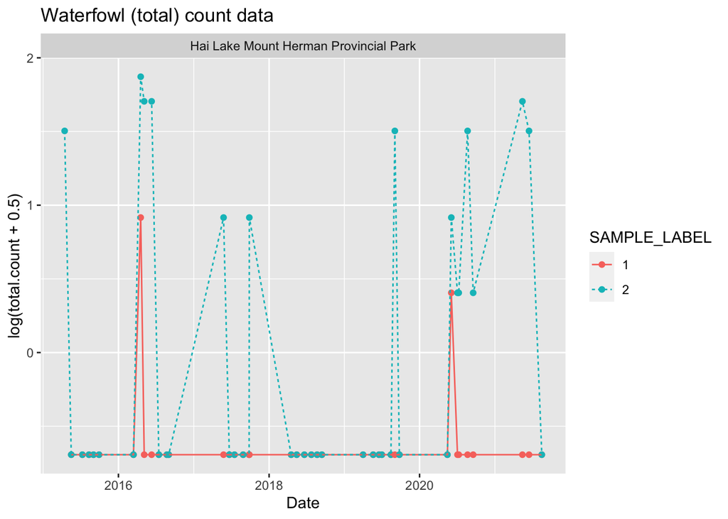

Figure 1: Summary plot of the data. Data is plotted on the logarithmic scale because of the wide range of values. Because of potential zeros in the data, 0.5 was added to all points only for plotting purposes.

Notice that there may be evidence of station effect, where for example, the number of birds at certain stations are generally higher than at the other stations because of local station-specific conditions (e.g. better habitat).

```
                         STUDY_AREA_NAME SAMPLE_LABEL Year Month max.count
1  Hai Lake Mount Herman Provincial Park            1 2015     5         0
2  Hai Lake Mount Herman Provincial Park            1 2015     7         0
3  Hai Lake Mount Herman Provincial Park            1 2015     8         0
4  Hai Lake Mount Herman Provincial Park            1 2015     9         0
5  Hai Lake Mount Herman Provincial Park            1 2016     3         0
6  Hai Lake Mount Herman Provincial Park            1 2016     4         2
7  Hai Lake Mount Herman Provincial Park            1 2016     5         0
8  Hai Lake Mount Herman Provincial Park            1 2016     6         0
9  Hai Lake Mount Herman Provincial Park            1 2016     7         0
10 Hai Lake Mount Herman Provincial Park            1 2016     8         0
11 Hai Lake Mount Herman Provincial Park            1 2016     9         0
12 Hai Lake Mount Herman Provincial Park            1 2017     5         0
13 Hai Lake Mount Herman Provincial Park            1 2017     6         0
14 Hai Lake Mount Herman Provincial Park            1 2017     7         0
```

[output cut: 59 more lines]

When the maximum counts are restricted to November, December, January, and February, the data are now:

```
[1] STUDY_AREA_NAME SAMPLE_LABEL    Year            Month
[5] max.count
<0 rows> (or 0-length row.names)
```

```
*** ERROR *** No data left to analyze when restricting data to J/F/N/D months
```